# O.4 Frontiers OXT

#### 4.4.2.13 IOS_Pre_OGL IOS_Post_OGL IOS_Pre_ECRAN IOS_Post_ECRAN

#### 4.4.2.14 Descriptives

| item | group1 | group2 | vars | n | mean | sd | median | trimmed | mad | min | max | range | skew | kurtosis | se |
| --- | --- | --- | --- | --- | --- | --- | --- | --- | --- | --- | --- | --- | --- | --- | --- |
| 1 | Post | ECRAN | 1 | 16 | 2.6875 | 1.851801 | 2 | 2.500000 | 1.4826 | 1 | 7 | 6 | 1.0207554 | -0.1493190 | 0.4629502 |
| 2 | Pre | ECRAN | 1 | 16 | 2.5625 | 1.459166 | 2 | 2.428571 | 1.4826 | 1 | 6 | 5 | 0.8501049 | -0.1918292 | 0.3647916 |
| 3 | Post | OGL | 1 | 16 | 3.5000 | 1.966384 | 4 | 3.428571 | 2.9652 | 1 | 7 | 6 | 0.1726212 | -1.4282105 | 0.4915960 |
| 4 | Pre | OGL | 1 | 16 | 2.6875 | 1.621471 | 2 | 2.571429 | 1.4826 | 1 | 6 | 5 | 0.8277533 | -0.4655066 | 0.4053676 |

NA

| .y. | group1 | group2 | p | p.adj | p.format | p.signif | method |
| --- | --- | --- | --- | --- | --- | --- | --- |
| value | IOS_Pre_OGL | IOS_Post_OGL | 0.05454827 | 0.33 | 0.055 | ns | T-test |
| value | IOS_Pre_OGL | IOS_Pre_ECRAN | 0.77856530 | 1.00 | 0.779 | ns | T-test |
| value | IOS_Pre_OGL | IOS_Post_ECRAN | 1.00000000 | 1.00 | 1.000 | ns | T-test |
| value | IOS_Post_OGL | IOS_Pre_ECRAN | 0.14437607 | 0.72 | 0.144 | ns | T-test |
| value | IOS_Post_OGL | IOS_Post_ECRAN | 0.24127702 | 0.97 | 0.241 | ns | T-test |
| value | IOS_Pre_ECRAN | IOS_Post_ECRAN | 0.49731055 | 1.00 | 0.497 | ns | T-test |

#### 4.4.2.15 t Change

| estimate | statistic | p.value | parameter | conf.low | conf.high | method | alternative |
| --- | --- | --- | --- | --- | --- | --- | --- |
| 0.6875 | 1.580051 | 0.1349477 | 15 | -0.2399204 | 1.61492 | Paired t-test | two.sided |

#### 4.4.2.16 ANCOVA Post

##### 4.4.2.16.1 Homogeneity test

| F | df1 | df2 | p |
| --- | --- | --- | --- |
| 0.6154284 | 1 | 30 | 0.4389022 |

##### 4.4.2.16.2 ANCOVA output

| name | ss | df | ms | F | p | etaSq | etaSqP |
| --- | --- | --- | --- | --- | --- | --- | --- |
| Pre | 65.381403 | 1 | 65.381403 | 43.037419 | 0.000000346759 | 0.57721086 | 0.59743144 |
| OglEcran | 3.833763 | 1 | 3.833763 | 2.523581 | 0.123000110922 | 0.03384586 | 0.08005376 |
| Residuals | 44.056097 | 29 | 1.519176 | NA | NA | NA | NA |

##### 4.4.2.16.3 Post Hoc

| OglEcran1 | sep | OglEcran2 | md | se | df | t | ptukey |
| --- | --- | --- | --- | --- | --- | --- | --- |
| ECRAN | - | OGL | -0.6928634 | 0.4361531 | 29 | -1.588578 | 0.1230001 |

##### 4.4.2.16.4 Homogeneity of regression slopes

[figure not shown]

## 4.5 Not considering Cond (OglEcran) - Overall Pre-Post

```r
# Data
vars_OglEcran <- grep("OGL|ECRAN", colnames(Data_merged_wide_all))

Data_notOglEcran <-
  Data_merged_wide_all %>%
  gather(variable, value, vars_OglEcran, -c(ID)) %>%                                      # gather Data and Nr_zi as these are OglEcran level
  tidyr::separate(variable,  c("variable", "OglEcran"), "_(?=[^_]+$)") %>%                # split only on last "_"
  spread(variable, value) %>%
  rename_at(vars(vars_OglEcran), list(~stringr::str_remove_all(., c("_OGL|_ECRAN")))) %>%
  mutate_at(vars(c(45:46, 48:53)), list(~as.numeric(as.character(.)))) %>%
  mutate(Diff_OXT = OXT_Post - OXT_Pre,
         Diff_Vas_Stres = Vas_Stres_Post - Vas_Stres_Pre,
         Diff_Vas_Bine = Vas_Bine_Post - Vas_Bine_Pre
  ) %>%
  arrange(ID)


# Simple before-after analyses with t test Not considering Cond (OglEcran)
Data_notOglEcran %>%
  filter(!ID %in% c(19, 43)) %>%
  func_t_box("ID", "OXT_Pre", "OXT_Post")    # JUST SHY OF SIG
```

#### 4.5.0.1 OXT_Pre OXT_Post

| .y. | group1 | group2 | p | p.adj | p.format | p.signif | method |
| --- | --- | --- | --- | --- | --- | --- | --- |
| value | OXT_Pre | OXT_Post | 0.05603378 | 0.056 | 0.056 | ns | T-test |

| estimate | statistic | p.value | parameter | conf.low | conf.high | method | alternative |
| --- | --- | --- | --- | --- | --- | --- | --- |
| -0.06441876 | -1.935499 | 0.05603378 | 91 | -0.1305309 | 0.001693375 | Paired t-test | two.sided |

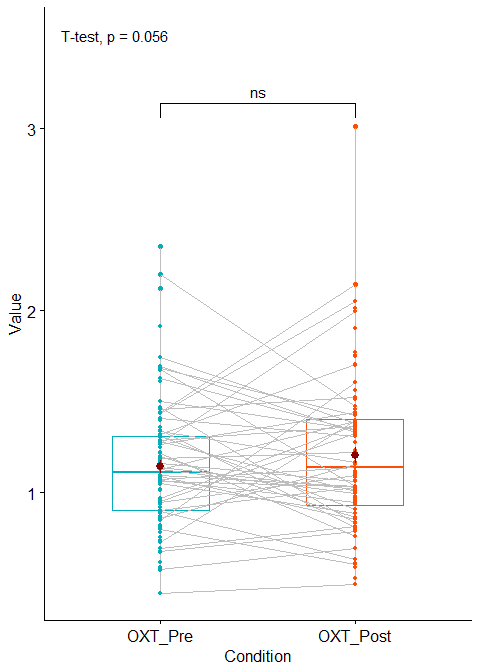

```r
func_t_box(Data_notOglEcran, "ID", "Vas_Stres_Pre", "Vas_Stres_Post")         # sig
```

#### 4.5.0.2 Vas_Stres_Pre Vas_Stres_Post

| .y. | group1 | group2 | p | p.adj | p.format | p.signif | method |
| --- | --- | --- | --- | --- | --- | --- | --- |
| value | Vas_Stres_Pre | Vas_Stres_Post | 0.00110996 | 0.0011 | 0.0011 | ** | T-test |

| estimate | statistic | p.value | parameter | conf.low | conf.high | method | alternative |
| --- | --- | --- | --- | --- | --- | --- | --- |
| 3.30303 | 3.360516 | 0.00110996 | 98 | 1.35251 | 5.253551 | Paired t-test | two.sided |

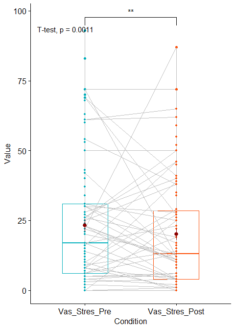

```r
func_t_box(Data_notOglEcran, "ID", "Vas_Bine_Pre", "Vas_Bine_Post")           # sig
```

#### 4.5.0.3 Vas_Bine_Pre Vas_Bine_Post

| .y. | group1 | group2 | p | p.adj | p.format | p.signif | method |
| --- | --- | --- | --- | --- | --- | --- | --- |
| value | Vas_Bine_Pre | Vas_Bine_Post | 0.007375202 | 0.0074 | 0.0074 | ** | T-test |

| estimate | statistic | p.value | parameter | conf.low | conf.high | method | alternative |
| --- | --- | --- | --- | --- | --- | --- | --- |
| -2.89899 | -2.736425 | 0.007375202 | 98 | -5.00135 | -0.7966296 | Paired t-test | two.sided |

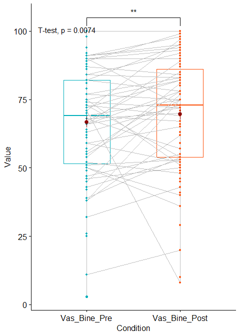

```r
func_t_box(Data_notOglEcran, "ID", "IOS_Pre", "IOS_Post")                     # sig
```

#### 4.5.0.4 IOS_Pre IOS_Post

| .y. | group1 | group2 | p | p.adj | p.format | p.signif | method |
| --- | --- | --- | --- | --- | --- | --- | --- |
| value | IOS_Pre | IOS_Post | 0.00002382733 | 0.000024 | 0.000024 | **** | T-test |

| estimate | statistic | p.value | parameter | conf.low | conf.high | method | alternative |
| --- | --- | --- | --- | --- | --- | --- | --- |
| -0.5058824 | -4.47496 | 0.00002382733 | 84 | -0.7306894 | -0.2810753 | Paired t-test | two.sided |

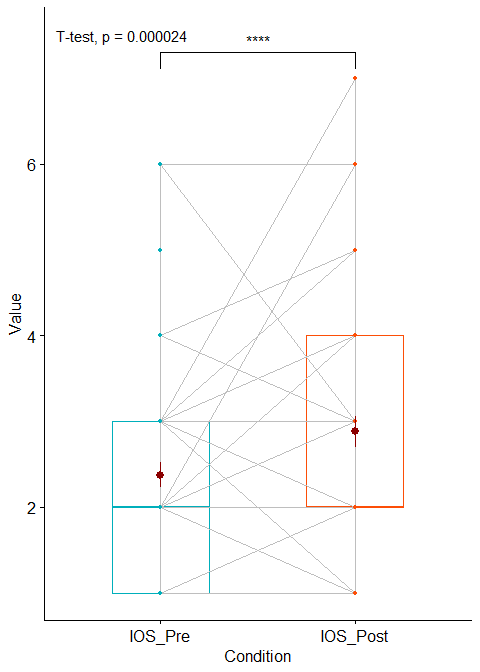

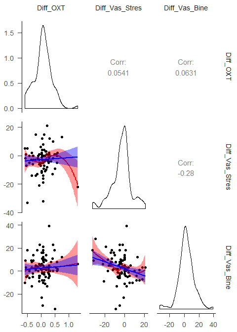

```r
# GGpairs
fn_ggpair_reg <- function(data, mapping, ...){
  p <- ggplot(data = data, mapping = mapping) +
    geom_point() +
    geom_smooth(method=loess, fill="red", color="red", ...) +
    geom_smooth(method=lm, fill="blue", color="blue", ...)
  p
}

GGally::ggpairs(data = Data_notOglEcran %>% filter(!ID %in% c(19, 43)),
                columns = 54:56,
                lower = list(continuous = fn_ggpair_reg))
```

## 4.6 Difference scores conditioned on Anxiety ?

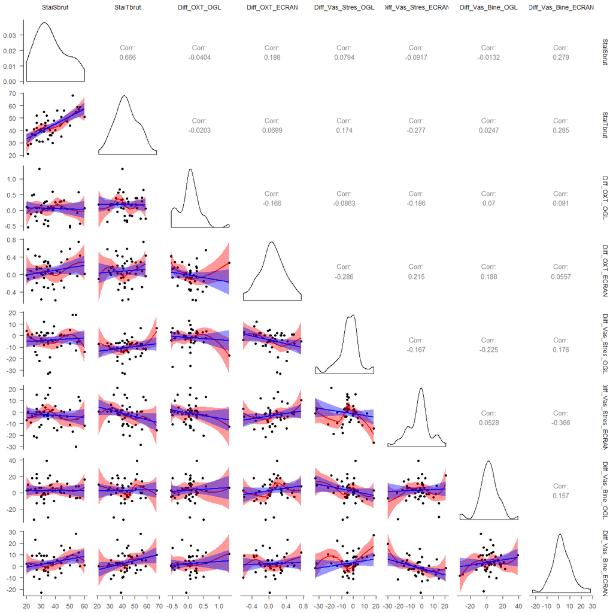

```r
plot_columns <- match( c("StaiSbrut", "StaiTbrut",
                         "Diff_OXT_OGL", "Diff_OXT_ECRAN",
                         "Diff_Vas_Stres_OGL", "Diff_Vas_Stres_ECRAN",
                         "Diff_Vas_Bine_OGL", "Diff_Vas_Bine_ECRAN"),
                          names(Data_difscores))

# GGpairs
fn_ggpair_reg <- function(data, mapping, ...){
  p <- ggplot(data = data, mapping = mapping) +
    geom_point() +
    geom_smooth(method=loess, fill="red", color="red", ...) +
    geom_smooth(method=lm, fill="blue", color="blue", ...)
  p
}

GGally::ggpairs(data = Data_difscores,
                columns = plot_columns,
                lower = list(continuous = fn_ggpair_reg))
```

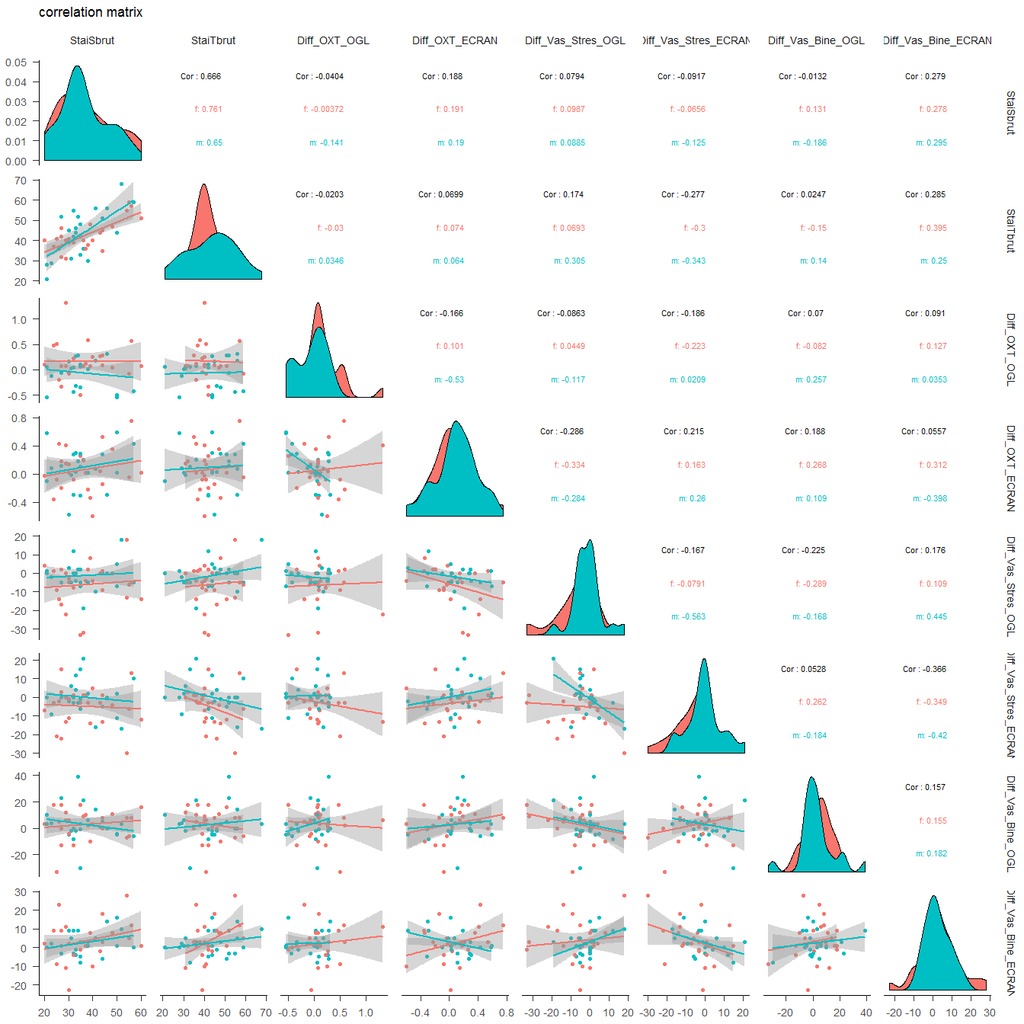

```r
# GGpairs By Gen
GGally::ggpairs(data = Data_difscores,
                columns = plot_columns,
                title = "correlation matrix",
                mapping = aes(colour = Gen),
                lower = list(
                continuous = "smooth",
                combo = "facetdensity",
                mapping = aes(color = Gen)),
                upper = list(continuous = wrap("cor", size = 3, hjust=0.8)))
```

```r
# Coplot Anx
Data_difscores %>%
  filter(!ID %in% c(19, 43)) %>%
    coplot(Diff_OXT_OGL ~ Diff_Vas_Stres_OGL | StaiTbrut,
           data = .,
           rows = 1,
           panel = function(x, y, ...) {
           panel.smooth(x, y, span = .8, iter = 5,...)
           abline(lm(y ~ x), col = "blue")})
```

Missing rows: 17, 26, 34, 43

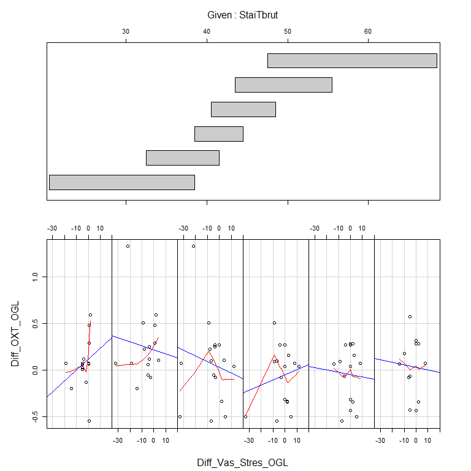

```r
Data_difscores %>%
  filter(!ID %in% c(19, 43)) %>%
    coplot(Diff_OXT_ECRAN ~ Diff_Vas_Stres_ECRAN | StaiTbrut,
           data = .,
           rows = 1,
           panel = function(x, y, ...) {
           panel.smooth(x, y, span = .8, iter = 5,...)
           abline(lm(y ~ x), col = "blue")})
```

Missing rows: 17, 26, 34, 43

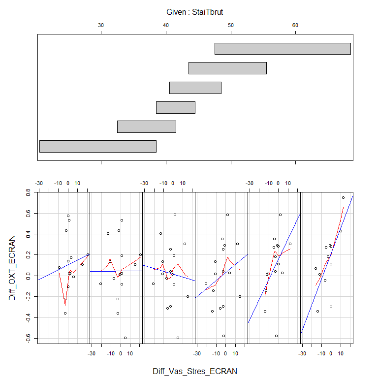

```r
Data_difscores %>%
  filter(!ID %in% c(19, 43)) %>%
  coplot(Diff_OXT_OGL ~ Diff_Vas_Stres_OGL | StaiSbrut,
         data = .,
         rows = 1,
         panel = function(x, y, ...) {
           panel.smooth(x, y, span = .8, iter = 5,...)
           abline(lm(y ~ x), col = "blue")})
```

Missing rows: 17, 26, 34, 43

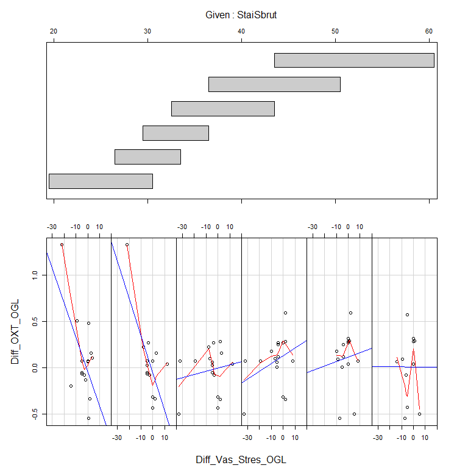

```r
Data_difscores %>%
  filter(!ID %in% c(19, 43)) %>%
  coplot(Diff_OXT_ECRAN ~ Diff_Vas_Stres_ECRAN | StaiSbrut,
         data = .,
         rows = 1,
         panel = function(x, y, ...) {
           panel.smooth(x, y, span = .8, iter = 5,...)
           abline(lm(y ~ x), col = "blue")})
```

Missing rows: 17, 26, 34, 43

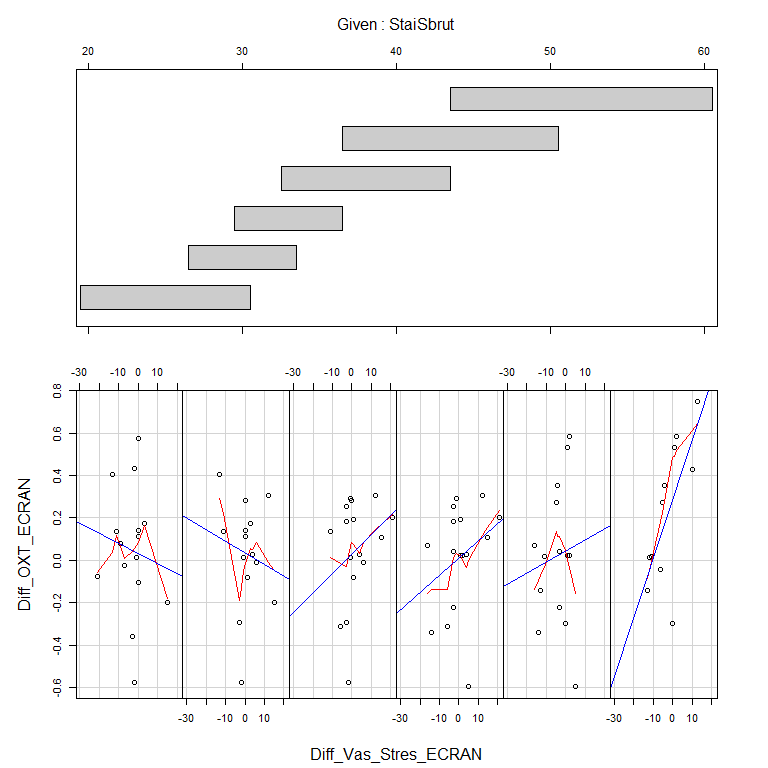

## 4.7 Difference scores conditioned on Extraversion ?

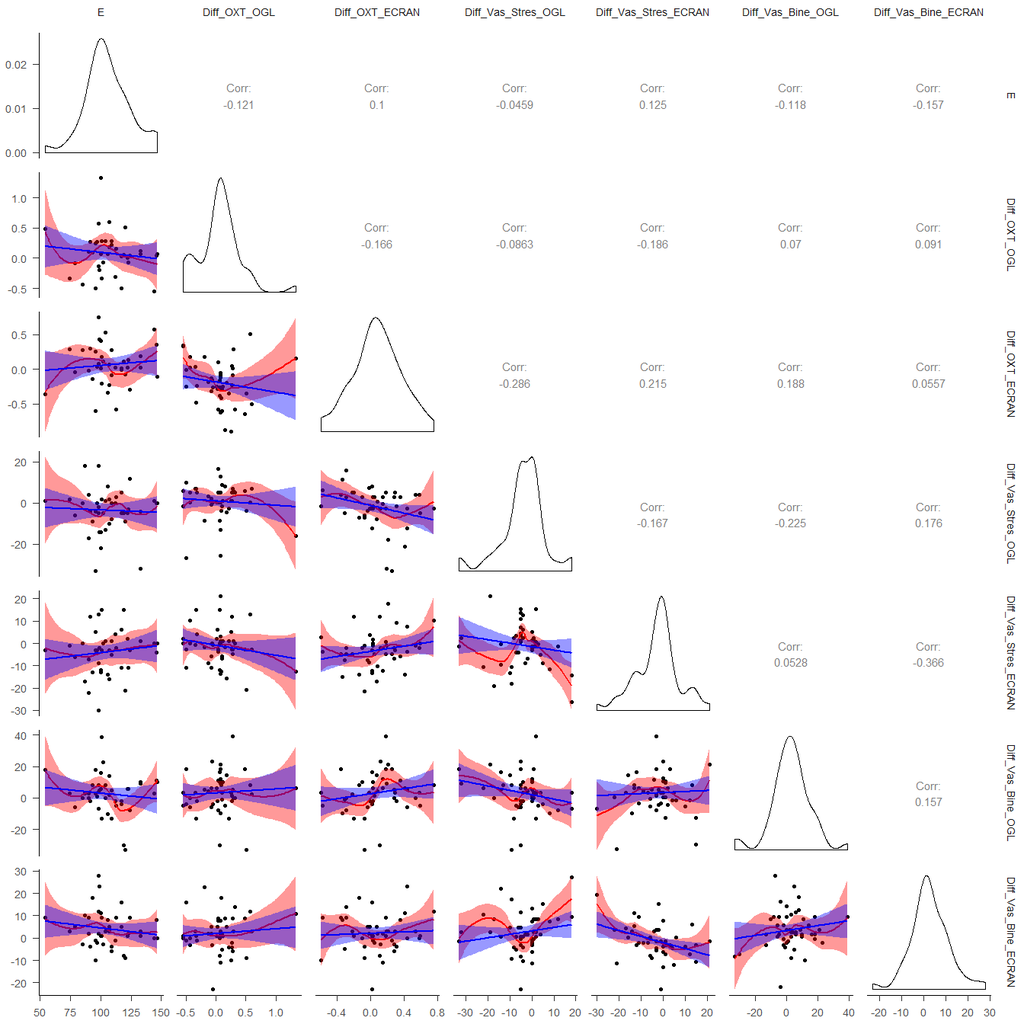

```r
plot_columns <- match(c("E",
                        "Diff_OXT_OGL", "Diff_OXT_ECRAN",
                        "Diff_Vas_Stres_OGL", "Diff_Vas_Stres_ECRAN",
                        "Diff_Vas_Bine_OGL", "Diff_Vas_Bine_ECRAN"),
                        names(Data_difscores))

# GGpairs
fn_ggpair_reg <- function(data, mapping, ...){
  p <- ggplot(data = data, mapping = mapping) +
    geom_point() +
    geom_smooth(method=loess, fill="red", color="red", ...) +
    geom_smooth(method=lm, fill="blue", color="blue", ...)
  p
}

GGally::ggpairs(data = Data_difscores,
                columns = plot_columns,
                lower = list(continuous = fn_ggpair_reg))
```

```r
## Define Function
func_moderation <- function(Data, dep, mod, pred){
  moderation <-
    Data %>%
    medmod::mod(., dep = dep, mod = mod, pred = pred,
                ci = TRUE, estMethod = 'standard', test = TRUE, simpleSlopeEst = FALSE, simpleSlopePlot = TRUE)

  cat(paste("<b> Moderation: ", "Dep = ", dep, "Pred = ", pred, "Mod = ", mod, "</b>"))
  moderation$mod %>%
    knitr::kable(caption = "Moderation", digits = 3) %>%
    print()
  moderation$simpleSlope$plot %>%
    print()
}


Data_merged_wide_all %>%
  filter(!ID %in% c(19, 43)) %>%
  func_moderation(Data = ., dep = "OXT_Post_OGL", mod = "E", pred = "OXT_Pre_OGL")

Data_merged_wide_all %>%
  filter(!ID %in% c(19, 43)) %>%
  func_moderation(Data = ., dep = "OXT_Post_ECRAN", mod = "E", pred = "OXT_Pre_ECRAN")


cat("### ANCOVA - Extraversion")
df_ancova_e <-
  Data_merged_wide_all %>%
  select("ID", "OXT_Pre_OGL", "OXT_Post_OGL", "OXT_Pre_ECRAN", "OXT_Post_ECRAN", "E") %>%
  tidyr::drop_na() %>%
  gather("OXT_Pre_OGL", "OXT_Post_OGL", "OXT_Pre_ECRAN", "OXT_Post_ECRAN", key = "Cond", value = "value") %>%
  mutate(PrePost = case_when(stringr::str_detect(.$"Cond", "Pre") ~ "Pre",
                             stringr::str_detect(.$"Cond", "Post") ~ "Post",
                             TRUE ~ NA_character_),
         OglEcran = case_when(stringr::str_detect(.$"Cond", "OGL") ~ "OGL",
                              stringr::str_detect(.$"Cond", "ECRAN") ~ "ECRAN",
                              TRUE ~ NA_character_)) %>%
  mutate(PrePost = as.factor(PrePost),
         OglEcran = as.factor(OglEcran)) %>%
  select(-"Cond") %>%
  spread("PrePost", "value")


jmv::ancova(
    formula = Post ~ Pre + OglEcran + E,
    data = df_ancova_e,
    homo = TRUE,
    ss = "3",
    postHoc = ~ OglEcran,
    postHocCorr = list("tukey"),
    effectSize = list("eta", "partEta")
  )
```

```r
## Define Function
func_moderation <- function(Data, dep, mod, pred){
  moderation <-
    Data %>%
      medmod::mod(., dep = dep, mod = mod, pred = pred,
                  ci = TRUE, estMethod = 'standard', test = TRUE, simpleSlopeEst = FALSE, simpleSlopePlot = TRUE)

  cat(paste("<b> Moderation: ", "Dep = ", dep, "Pred = ", pred, "Mod = ", mod, "</b>"))
  moderation$mod %>%
    knitr::kable(caption = "Moderation", digits = 3) %>%
    print()
  moderation$simpleSlope$plot %>%
    print()
}

## Apply Function
Data_merged_wide_all %>%
  filter(!ID %in% c(19, 43)) %>%
  func_moderation(Data = ., dep = "OXT_Post_OGL", mod = "StaiTbrut", pred = "OXT_Pre_OGL")

Data_merged_wide_all %>%
  filter(!ID %in% c(19, 43)) %>%
  func_moderation(Data = ., dep = "OXT_Post_ECRAN", mod = "StaiTbrut", pred = "OXT_Pre_ECRAN")





# bla <-
#   Data_merged %>%
#   mutate(Conditie = as.numeric(as.factor(Conditie)))
#
# psych::mediate(data = bla, Oxitocina_post ~ Oxitocina_pre + Conditie + Vas_rel_global)   # moderation with covariate and diagram
```

## 4.8 Mixed Design ANOVA

```r
# Data
Data_mixedanova <-
  Data_merged_long_all %>%
  mutate(PrePost = case_when(stringr::str_detect(.$"PrePost", "Pre") ~ as.integer(0),
                             stringr::str_detect(.$"PrePost", "Post") ~ as.integer(1),
                             TRUE ~ NA_integer_)) %>%
  mutate(OglEcran = case_when(stringr::str_detect(.$"OglEcran", "ECRAN") ~ as.integer(0),
                           stringr::str_detect(.$"OglEcran", "OGL") ~ as.integer(1),
                           TRUE ~ NA_integer_)) %>%
  mutate(StaiTbrut_dih = sjmisc::dicho(.$"StaiTbrut",
                                       dich.by = "median", as.num = FALSE,                                # similar to Hmisc::cut2, but uses median
                                       val.labels = c("lower", "higher"), append = FALSE)) %>%
  select(ID, OglEcran, PrePost, OXT, StaiTbrut_dih) %>%
  drop_na()


# Mixed Design Anova  # http://www.cookbook-r.com/Statistical_analysis/ANOVA/
aov_mixed1 <- aov(OXT ~ OglEcran * PrePost * StaiTbrut_dih + Error(ID/PrePost), data = Data_mixedanova)
broom::tidy(aov_mixed1)
# summary(aov_mixed1)
# model.tables(aov_mixed1, "means")   # is data balanced?




# library(jtools)
# mod1 <- lm(OXT_Post_OGL ~ OXT_Pre_OGL * StaiTbrut, data = Data_mixedanova)
# jtools::summ(mod1)
# jtools::interact_plot(mod1, pred = OXT_Pre_OG, modx = StaiTbrut)
#
# library(interactions)
```

## 4.9 Correlations between Diff_OXT_OGL with other variables

```r
## Correlations between Diffrence Scores with other variables
Data_difscores[,-c(1:2, 5:24)] %>%
  Correlations_With_One(., variable = "Diff_OXT_OGL", correlation_abs_threshold = 0.2, pvalue_threshold = 0.05)   # nothing
```

#### 4.9.0.1 Correlations with Diff_OXT_OGL

| Variable | correlation | p.value | p.signif |
| --- | --- | --- | --- |

```r
####
Data_difscores[,-c(1:2, 5:24)] %>%
   Correlations_With_One(., variable = "Diff_Vas_Stres_OGL", correlation_abs_threshold = 0.2, pvalue_threshold = 0.05) # C,C5
```

#### 4.9.0.2 Correlations with Diff_Vas_Stres_OGL

| Variable | correlation | p.value | p.signif |
| --- | --- | --- | --- |
| C | -0.3401997 | 0.02749435 | * |
| C5 | -0.3158566 | 0.04157954 | * |

```r
###
Data_difscores[,-c(1:2, 5:24)] %>%
   Correlations_With_One(., variable = "Diff_Vas_Bine_OGL", correlation_abs_threshold = 0.2, pvalue_threshold = 0.05)  # BDI
```

#### 4.9.0.3 Correlations with Diff_Vas_Bine_OGL

| Variable | correlation | p.value | p.signif |
| --- | --- | --- | --- |
| ScorBDI | -0.3215483 | 0.02278478 | * |

```r
Data_difscores[,-c(1:2, 5:24)] %>%
   Correlations_With_One(., variable = "Diff_Vas_Bine_ECRAN", correlation_abs_threshold = 0.2, pvalue_threshold = 0.05) # O2,O3, StaiT
```

#### 4.9.0.4 Correlations with Diff_Vas_Bine_ECRAN

| Variable | correlation | p.value | p.signif |
| --- | --- | --- | --- |
| O2 | 0.4192279 | 0.006366208 | ** |
| Diff_Vas_Stres_ECRAN | -0.3664764 | 0.009600262 | ** |
| O3 | 0.3951386 | 0.010561811 | * |
| StaiTbrut | 0.2849967 | 0.047161039 | * |

```r
lm(Vas_Stres_Post_OGL ~ Vas_Stres_Pre_OGL + StaiTbrut, data = Data_merged_wide_all) %>% summary()      # sig
```

Call: lm(formula = Vas_Stres_Post_OGL ~ Vas_Stres_Pre_OGL + StaiTbrut, data = Data_merged_wide_all)

Residuals: Min 1Q Median 3Q Max -18.513 -4.540 1.046 3.503 20.137

Coefficients: Estimate Std. Error t value Pr(>|t|)  
(Intercept) -9.31395 5.38906 -1.728 0.0905 .  
Vas_Stres_Pre_OGL 0.73616 0.05491 13.406 <0.0000000000000002 ** *StaiTbrut 0.26002 0.12212 2.129 0.0385*  
— Signif. codes: 0 ‘**’ 0.001 ‘**’ 0.01 ‘’ 0.05 ‘.’ 0.1 ‘ ’ 1

Residual standard error: 8.039 on 47 degrees of freedom Multiple R-squared: 0.8065, Adjusted R-squared: 0.7983 F-statistic: 97.97 on 2 and 47 DF, p-value: < 0.00000000000000022

```r
lm(Vas_Stres_Post_ECRAN ~ Vas_Stres_Pre_ECRAN + StaiTbrut, data = Data_merged_wide_all) %>% summary()  # ns
```

Call: lm(formula = Vas_Stres_Post_ECRAN ~ Vas_Stres_Pre_ECRAN + StaiTbrut, data = Data_merged_wide_all)

Residuals: Min 1Q Median 3Q Max -23.0762 -4.4267 -0.5844 4.6774 19.2660

Coefficients: Estimate Std. Error t value Pr(>|t|)  
(Intercept) 7.34215 6.03290 1.217 0.230  
Vas_Stres_Pre_ECRAN 0.83186 0.05658 14.702 <0.0000000000000002 *** StaiTbrut -0.13710 0.14472 -0.947 0.348  
— Signif. codes: 0 ‘**’ 0.001 ‘**’ 0.01 ‘’ 0.05 ‘.’ 0.1 ‘ ’ 1

Residual standard error: 8.858 on 46 degrees of freedom (1 observation deleted due to missingness) Multiple R-squared: 0.8373, Adjusted R-squared: 0.8302 F-statistic: 118.4 on 2 and 46 DF, p-value: < 0.00000000000000022

```r
lm(Vas_Bine_Post_OGL ~ Vas_Bine_Pre_OGL + ScorBDI, data = Data_merged_wide_all) %>% summary()        # sig
```

Call: lm(formula = Vas_Bine_Post_OGL ~ Vas_Bine_Pre_OGL + ScorBDI, data = Data_merged_wide_all)

Residuals: Min 1Q Median 3Q Max -31.928 -7.000 0.981 6.480 31.480

Coefficients: Estimate Std. Error t value Pr(>|t|)  
(Intercept) 15.69505 6.62844 2.368 0.0221 *  
Vas_Bine_Pre_OGL 0.89920 0.08809 10.208 0.000000000000164 ** *ScorBDI -0.62074 0.26139 -2.375 0.0217*  
— Signif. codes: 0 ‘**’ 0.001 ‘**’ 0.01 ‘’ 0.05 ‘.’ 0.1 ‘ ’ 1

Residual standard error: 11.54 on 47 degrees of freedom Multiple R-squared: 0.7015, Adjusted R-squared: 0.6888 F-statistic: 55.24 on 2 and 47 DF, p-value: 0.0000000000004571

```r
lm(Vas_Bine_Post_ECRAN ~ Vas_Bine_Pre_ECRAN + ScorBDI, data = Data_merged_wide_all) %>% summary()    # ns
```

Call: lm(formula = Vas_Bine_Post_ECRAN ~ Vas_Bine_Pre_ECRAN + ScorBDI, data = Data_merged_wide_all)

Residuals: Min 1Q Median 3Q Max -21.9414 -4.4338 -0.7211 5.6113 23.7907

Coefficients: Estimate Std. Error t value Pr(>|t|)  
(Intercept) 10.67270 5.16231 2.067 0.0443 *  
Vas_Bine_Pre_ECRAN 0.90116 0.06273 14.366 <0.0000000000000002 *** ScorBDI -0.10869 0.20274 -0.536 0.5945  
— Signif. codes: 0 ‘**’ 0.001 ‘**’ 0.01 ‘’ 0.05 ‘.’ 0.1 ‘ ’ 1

Residual standard error: 8.741 on 46 degrees of freedom (1 observation deleted due to missingness) Multiple R-squared: 0.8259, Adjusted R-squared: 0.8183 F-statistic: 109.1 on 2 and 46 DF, p-value: < 0.00000000000000022

## 4.10 Correlations between Diff_OXT_OGL with other variables - by Gender

```r
## Correlations between Diffrence Scores with other variables - Females
cat("### Females")
```

### 4.10.1 Females

```r
Data_difscores[,-c(1:2, 5:24)] %>%
  filter(Gen == "f") %>%
  Correlations_With_One(., variable = "Diff_OXT_OGL", correlation_abs_threshold = 0.2, pvalue_threshold = 0.05)   # nothing
```

#### 4.10.1.1 Correlations with Diff_OXT_OGL

| Variable | correlation | p.value | p.signif |
| --- | --- | --- | --- |

```r
####
Data_difscores[,-c(1:2, 5:24)]%>%
  filter(Gen == "f") %>%
   Correlations_With_One(., variable = "Diff_Vas_Stres_OGL", correlation_abs_threshold = 0.2, pvalue_threshold = 0.05) # A1
```

#### 4.10.1.2 Correlations with Diff_Vas_Stres_OGL

| Variable | correlation | p.value | p.signif |
| --- | --- | --- | --- |
| A1 | -0.4572241 | 0.02468362 | * |

```r
###
Data_difscores[,-c(1:2, 5:24)] %>%
  filter(Gen == "f") %>%
  Correlations_With_One(., variable = "Diff_Vas_Bine_OGL", correlation_abs_threshold = 0.2, pvalue_threshold = 0.05)  # BDI, N2
```

#### 4.10.1.3 Correlations with Diff_Vas_Bine_OGL

| Variable | correlation | p.value | p.signif |
| --- | --- | --- | --- |
| ScorBDI | -0.5216924 | 0.005256735 | ** |
| N2 | -0.4190081 | 0.041549297 | * |

```r
Data_difscores[,-c(1:2, 5:24)] %>%
  filter(Gen == "f") %>%
  Correlations_With_One(., variable = "Diff_Vas_Bine_ECRAN", correlation_abs_threshold = 0.2, pvalue_threshold = 0.05) # StaiT
```

#### 4.10.1.4 Correlations with Diff_Vas_Bine_ECRAN

| Variable | correlation | p.value | p.signif |
| --- | --- | --- | --- |
| StaiTbrut | 0.3951891 | 0.0456998 | * |

```r
## Correlations between Diffrence Scores with other variables - Males
cat("### Males")
```

### 4.10.2 Males

```r
Data_difscores[,-c(1:2, 5:24)] %>%
  filter(Gen == "m") %>%
  Correlations_With_One(., variable = "Diff_OXT_OGL", correlation_abs_threshold = 0.2, pvalue_threshold = 0.05)   # O6,A6
```

#### 4.10.2.1 Correlations with Diff_OXT_OGL

| Variable | correlation | p.value | p.signif |
| --- | --- | --- | --- |
| O6 | -0.7059720 | 0.001540276 | ** |
| A6 | -0.6050772 | 0.010067122 | * |
| Diff_OXT_ECRAN | -0.5304657 | 0.011093564 | * |

```r
####
Data_difscores[,-c(1:2, 5:24)] %>%
  filter(Gen == "m") %>%
  Correlations_With_One(., variable = "Diff_Vas_Stres_OGL", correlation_abs_threshold = 0.2, pvalue_threshold = 0.05) # C2-Ordine!!!
```

#### 4.10.2.2 Correlations with Diff_Vas_Stres_OGL

| Variable | correlation | p.value | p.signif |
| --- | --- | --- | --- |
| Diff_Vas_Stres_ECRAN | -0.5629853 | 0.005159213 | ** |
| Diff_IOS_ECRAN | -0.5359708 | 0.032354934 | * |
| Diff_Vas_Bine_ECRAN | 0.4446902 | 0.033496698 | * |
| C2 | -0.4867040 | 0.040531507 | * |

```r
###
Data_difscores[,-c(1:2, 5:24)] %>%
  filter(Gen == "m") %>%
  Correlations_With_One(., variable = "Diff_Vas_Bine_OGL", correlation_abs_threshold = 0.2, pvalue_threshold = 0.05)  # nothing
```

#### 4.10.2.3 Correlations with Diff_Vas_Bine_OGL

| Variable | correlation | p.value | p.signif |
| --- | --- | --- | --- |

```r
Data_difscores[,-c(1:2, 5:24)] %>%
  filter(Gen == "m") %>%
  Correlations_With_One(., variable = "Diff_Vas_Bine_ECRAN", correlation_abs_threshold = 0.2, pvalue_threshold = 0.05) # C2-Ordine,O2
```

#### 4.10.2.4 Correlations with Diff_Vas_Bine_ECRAN

| Variable | correlation | p.value | p.signif |
| --- | --- | --- | --- |
| O2 | 0.6793028 | 0.001931573 | ** |
| O3 | 0.6626201 | 0.002729768 | ** |
| O | 0.5643252 | 0.014700981 | * |
| C3 | -0.5579725 | 0.016115386 | * |
| C | -0.5538192 | 0.017096891 | * |
| C5 | -0.5507262 | 0.017858069 | * |
| C2 | -0.5497720 | 0.018098223 | * |
| Diff_Vas_Stres_OGL | 0.4446902 | 0.033496698 | * |
| Diff_Vas_Stres_ECRAN | -0.4203652 | 0.045802651 | * |

# 5 within-participant mediation

```r
library(JSmediation)

df_cordif_fem <-
  Data_difscores %>%
  filter(Gen == "f")

cor.test(df_cordif_fem$Diff_OXT_OGL, df_cordif_fem$Diff_Vas_Stres_OGL)  # ns
```

```
Pearson's product-moment correlation
```

data: df_cordif_fem$Diff_OXT_OGL and df_cordif_fem$Diff_Vas_Stres_OGL t = 0.21086, df = 22, p-value = 0.8349 alternative hypothesis: true correlation is not equal to 0 95 percent confidence interval: -0.3651008 0.4403297 sample estimates: cor 0.04491029

```r
summary(lm(Diff_OXT_OGL ~ Diff_Vas_Stres_OGL, data = df_cordif_fem))   # ns
```

Call: lm(formula = Diff_OXT_OGL ~ Diff_Vas_Stres_OGL, data = df_cordif_fem)

Residuals: Min 1Q Median 3Q Max -0.62386 -0.15832 -0.07481 0.09697 1.18405

Coefficients: Estimate Std. Error t value Pr(>|t|)  
(Intercept) 0.176485 0.089349 1.975 0.0609 . Diff_Vas_Stres_OGL 0.001570 0.007445 0.211 0.8349  
— Signif. codes: 0 ‘**’ 0.001 ‘**’ 0.01 ‘’ 0.05 ‘.’ 0.1 ‘ ’ 1

Residual standard error: 0.3689 on 22 degrees of freedom (3 observations deleted due to missingness) Multiple R-squared: 0.002017, Adjusted R-squared: -0.04335 F-statistic: 0.04446 on 1 and 22 DF, p-value: 0.8349

```r
withinmed_OGL <-
  mdt_within_wide(data = Data_fem,
                  DV_A = Vas_Stres_Pre_OGL, DV_B = Vas_Stres_Post_OGL,
                  M_A = OXT_Pre_OGL, M_B = OXT_Post_OGL)
add_index(withinmed_OGL)
```

# 6 Test of mediation (within-participant mediation)

Variables:

- DV difference: Vas_Stres_Pre_OGL - Vas_Stres_Post_OGL
- M difference: OXT_Pre_OGL - OXT_Post_OGL

Paths:

==== ============== ===== ====================== Path Point estimate SE APA  
==== ============== ===== ====================== a -0.166 0.074 t(23) = 2.26, p = .034 b 3.656 6.764 t(21) = 0.54, p = .595 c 6.185 2.137 t(26) = 2.89, p = .008 c’ 7.067 2.444 t(21) = 2.89, p = .009 ==== ============== ===== ======================

Indirect effect index:

- type: Within-participant indirect effect
- point estimate: -0.608
- confidence interval:
  - method: Monte Carlo (5000 iterations)
  - level: 0.05
  - CI: [-3.37; 1.77]

Fitted models:

- 1 -> DV_diff
- 1 -> M_diff
- 1 + M_diff + M_mean -> DV_diff

```r
withinmed_ECRAN <-
  mdt_within_wide(data = Data_fem,
                  DV_A = Vas_Stres_Pre_ECRAN, DV_B = Vas_Stres_Post_ECRAN,
                  M_A = OXT_Pre_ECRAN, M_B = OXT_Post_ECRAN)
add_index(withinmed_ECRAN)
```

# 7 Test of mediation (within-participant mediation)

Variables:

- DV difference: Vas_Stres_Pre_ECRAN - Vas_Stres_Post_ECRAN
- M difference: OXT_Pre_ECRAN - OXT_Post_ECRAN

Paths:

==== ============== ===== ====================== Path Point estimate SE APA  
==== ============== ===== ====================== a -0.058 0.062 t(23) = 0.93, p = .360 b 4.307 5.702 t(21) = 0.76, p = .458 c 4.923 1.988 t(25) = 2.48, p = .020 c’ 3.417 1.731 t(21) = 1.97, p = .062 ==== ============== ===== ======================

Indirect effect index:

- type: Within-participant indirect effect
- point estimate: -0.25
- confidence interval:
  - method: Monte Carlo (5000 iterations)
  - level: 0.05
  - CI: [-1.68; 0.631]

Fitted models:

- 1 -> DV_diff
- 1 -> M_diff
- 1 + M_diff + M_mean -> DV_diff

```r
# mdt_within_wide(data = Data_fem,                                             # ns
#                 DV_A = Vas_Bine_Pre_OGL, DV_B = Vas_Bine_Post_OGL,
#                 M_A = OXT_Pre_OGL, M_B = OXT_Post_OGL)

# mdt_within_wide(data = Data_fem,                                             # ns
#                 DV_A = IOS_Pre_OGL, DV_B = IOS_Post_OGL,
#                 M_A = OXT_Pre_OGL, M_B = OXT_Post_OGL)
```

## 7.1 Correlations with OxT

```r
## Mining Correlations with Oxy

# df_OxyAll_cor <-
#   Get_Top_Relationships(Data[,-c(1:7)], correlation_abs_threshold = 0.2, pvalue_threshold = 0.05) %>%
#     dplyr::as_tibble() %>%
#     dplyr::filter_all(any_vars(grepl("Ox", .)))                           # only Oxy, but both Pre and Post Oxy
#
# df_OxyAll_cor %>%
#     print(n = Inf)
# df_OxyAll_cor %>%
#   func_dotplot_cor()
#
# # Correlations only on Pre measures with Oxy -- nothing
# df_OxyPre_cor <-
#   Get_Top_Relationships(Data[,-c(1:7)], correlation_abs_threshold = 0.2, pvalue_threshold = 0.1) %>%
#     dplyr::as_tibble() %>%
#     filter_at(vars(feature_1, feature_2), all_vars(grepl("pre|Pre", .))) %>%
#     dplyr::filter_all(any_vars(grepl("Ox", .)))
```

A work by [Claudiu Papasteri](https://github.com/ClaudiuPapasteri/)

*claudiu.papasteri@gmail.com*